# TD 5 — Ajuster le modèle de Schaefer à des données

Introduction à l’halieutique — M2 Sciences de la Mer

Auteur·rice

Laurent Dubroca

Date de publication

23 novembre 2026

# Objectifs et consignes

Au TD précédent, vous avez **simulé** le modèle de Schaefer à partir de valeurs connues de $r$ et $K$. En pratique, c’est l’inverse : on observe des captures et un indice d’abondance, et l’on cherche les valeurs de $r$ et $K$ qui expliquent le mieux ces observations. C’est l’**ajustement** du modèle.

1. comprendre le principe de l’ajustement sur un cas simple, la régression linéaire : solution exacte, puis recherche numérique avec `optim()` ;
2. ajuster le modèle de Schaefer à des **données simulées**, dont on connaît les vraies valeurs des paramètres ;
3. ajuster le modèle à de **vraies données**, celles du thon germon de l’Atlantique Sud, et en déduire le MSY et l’état du stock.

**Durée** : environ 2 heures.

**Rendu** : ce document complété (`.qmd` **et** `.html`), à envoyer par mail à l’intervenant à la fin de la demi-journée. Il est noté. Commentez vos résultats à la place de *(commentez ici)*.

Cherchez par vous-même : la correction sera fournie après la séance.

```r
if (!requireNamespace("ggplot2", quietly = TRUE)) install.packages("ggplot2")
library(ggplot2)
```

# 1 Rappels

## 1.1 Le modèle et ses points de référence

Le modèle de Schaefer en temps discret s’écrit :

$$B_{t+1} = B_t + r\,B_t\left(1 - \frac{B_t}{K}\right) - C_t$$

avec $t$ l’année, $B_t$ la biomasse, $r$ le taux intrinsèque d’accroissement, $K$ la capacité de charge (biomasse d’équilibre du stock non exploité, ou biomasse vierge) et $C_t$ les captures.

On peut aussi l’écrire en temps continu :

$$\frac{dB}{dt} = rB \left(1 - \frac{B}{K}\right) - C$$

Le **rendement maximal durable** (RMD, ou MSY pour *Maximum Sustainable Yield*) est la plus grande capture que l’on peut prélever chaque année sans faire baisser le stock. À l’équilibre, la biomasse ne varie plus, donc sa dérivée s’annule :

$$\frac{dB}{dt} = 0
\quad\Leftrightarrow\quad
C = rB \left(1 - \frac{B}{K}\right)$$

Pour trouver le MSY, on cherche la biomasse qui maximise cette capture d’équilibre. On dérive donc $C$ par rapport à $B$ :

$$\frac{dC}{dB} = \left(rB - \frac{rB^2}{K}\right)'
= r - \frac{2rB}{K}
= r \left(1 - \frac{2B}{K} \right)$$

La dérivée s’annule pour la biomasse optimale $B_{MSY}$ :

$$r \left(1 - \frac{2B_{MSY}}{K} \right) = 0
\quad\Leftrightarrow\quad
\frac{2B_{MSY}}{K} = 1
\quad\Leftrightarrow\quad
B_{MSY} = \frac{K}{2}$$

On en déduit le rendement maximal durable :

$$MSY = rB_{MSY} \left(1 - \frac{B_{MSY}}{K}\right)
= r\frac{K}{2} \left(1 - \frac{1}{2}\right)
= \frac{rK}{4}$$

La mortalité par pêche correspondante est $F_{MSY} = MSY / B_{MSY} = r/2$.

Points de référence du modèle de Schaefer

| Point de référence | Formule |
| --- | --- |
| $B_{MSY}$ | $K/2$ |
| $MSY$ | $rK/4$ |
| $F_{MSY}$ | $r/2$ |

## 1.2 L’indice d’abondance

On ne peut presque jamais mesurer directement la biomasse d’un stock. On utilise à la place un **indice d’abondance** $I$, supposé proportionnel à la biomasse :

$$I_t = q\,B_t$$

où $q$ est le **coefficient de capturabilité**, inconnu et donc à estimer. L’indice peut être :

- une **capture par unité d’effort** (CPUE) : $C/E$, la capture divisée par l’effort de pêche d’une flottille bien suivie et au comportement stable ;
- un indice de **campagne scientifique**, indépendant de la pêche ;
- une estimation par marquage-recapture ou par acoustique.

L’hypothèse $I = qB$ est fragile : $q$ peut changer avec les techniques de pêche ou le comportement des poissons. Une CPUE stable peut ainsi masquer une baisse du stock si les pêcheurs deviennent plus efficaces.

**Le problème à résoudre** : connaissant les captures $C_t$ et l’indice $I_t$, trouver $r$, $K$ et $q$.

# 2 Le principe de l’ajustement : la régression linéaire

Avant le modèle de Schaefer, prenons le cas le plus simple. Il s’agit de reprendre les calculs qui donnent les coefficients d’une droite ajustée à un nuage de points : en théorie un rappel pratique, en pratique un rappel théorique.

## 2.1 La solution exacte

Soit deux variables $\{y_i, x_i\}_{i=1,\dots,n}$, où $x$ est la variable explicative et $y$ la variable à expliquer. On cherche à ajuster le modèle de régression linéaire :

$$y_i = a\,x_i + b + \epsilon_i$$

avec $\epsilon_i$ le terme d’erreur, $a$ la pente et $b$ l’ordonnée à l’origine. On utilise la méthode des **moindres carrés ordinaires** : $a$ et $b$ doivent minimiser la somme des carrés des erreurs. On suppose vérifiées les hypothèses habituelles : indépendance des erreurs, absence de corrélation entre variable explicative et erreur, variance constante (homoscédasticité), normalité des erreurs.

On cherche donc :

$$(\hat a, \hat b) = \underset{a,b}{\operatorname{argmin}} \; S(a, b)
\quad\text{avec}\quad
S(a, b) = \sum_{i=1}^{n}\epsilon_i^2 = \sum_{i=1}^{n}(y_i - a x_i - b)^2$$

« argmin » désigne les valeurs des arguments ($a$ et $b$) qui rendent $S$ minimale. $S$ est une fonction dérivable de deux variables réelles : son minimum annule ses deux dérivées partielles :

$$\begin{cases}
\dfrac{\partial S}{\partial a}(a,b) = 0\\[2mm]
\dfrac{\partial S}{\partial b}(a,b) = 0
\end{cases}$$

En utilisant la règle de dérivation $(u^2)' = 2u'u$ :

$$\begin{cases}
\dfrac{\partial S}{\partial b}(a,b) = -2\sum_{i=1}^{n}(y_i - a x_i - b) = 0\\[2mm]
\dfrac{\partial S}{\partial a}(a,b) = -2\sum_{i=1}^{n}x_i(y_i - a x_i - b) = 0
\end{cases}$$

La première équation donne :

$$\begin{aligned}
& \sum_{i=1}^{n}y_i - a\sum_{i=1}^{n}x_i - nb = 0\\
\Leftrightarrow\; & nb = \sum_{i=1}^{n}y_i - a\sum_{i=1}^{n}x_i\\
\Leftrightarrow\; & b = \frac{1}{n}\sum_{i=1}^{n}y_i - a\,\frac{1}{n}\sum_{i=1}^{n}x_i\\
\Leftrightarrow\; & b = \bar y - a\,\bar x
\end{aligned}$$

avec $\bar x$ et $\bar y$ les moyennes empiriques des $x_i$ et des $y_i$.

La deuxième équation donne :

$$\sum_{i=1}^{n}x_iy_i - a\sum_{i=1}^{n}x_i^2 - b\sum_{i=1}^{n}x_i = 0$$

En remplaçant $b$ par $\bar y - a\bar x$ :

$$\begin{aligned}
& \sum_{i=1}^{n}x_iy_i - a\sum_{i=1}^{n}x_i^2 - (\bar y - a\bar x)\sum_{i=1}^{n}x_i = 0\\
\Leftrightarrow\; & a\left(\sum_{i=1}^{n}x_i^2 - \bar x\sum_{i=1}^{n}x_i\right) = \sum_{i=1}^{n}x_iy_i - \bar y\sum_{i=1}^{n}x_i\\
\Leftrightarrow\; & a = \frac{\sum_{i=1}^{n}x_i(y_i - \bar y)}{\sum_{i=1}^{n}x_i(x_i - \bar x)}\\
\Leftrightarrow\; & a = \frac{\sum_{i=1}^{n}(x_i - \bar x)(y_i - \bar y)}{\sum_{i=1}^{n}(x_i - \bar x)^2}
\end{aligned}$$

La dernière ligne utilise le fait que $\sum_i \bar x (y_i - \bar y) = 0$ et $\sum_i \bar x (x_i - \bar x) = 0$.

En résumé, la droite des moindres carrés a pour pente et ordonnée à l’origine :

$$\hat a = \frac{\sum_{i=1}^{n}(x_i - \bar x)(y_i - \bar y)}{\sum_{i=1}^{n}(x_i - \bar x)^2}
\qquad
\hat b = \bar y - \hat a\,\bar x$$

Appliquons ces formules à un petit jeu de données :

```r
df <- data.frame(x = c(1, 3, 4, 9), y = c(1, 5, 7, 8))
df
```

```
  x y
1 1 1
2 3 5
3 4 7
4 9 8
```

```r
a_exact <- sum((df$x - mean(df$x)) * (df$y - mean(df$y))) / sum((df$x - mean(df$x))^2)
b_exact <- mean(df$y) - a_exact * mean(df$x)
c(a = a_exact, b = b_exact)
```

```
        a         b
0.7697842 1.9784173
```

## 2.2 La solution numérique : `optim()`

Pour la régression linéaire, on a pu résoudre le problème à la main. Pour le modèle de Schaefer, ce sera impossible : la biomasse dépend de $r$ et $K$ à travers une boucle sur les années. On utilise alors un **algorithme d’optimisation**, qui essaie des valeurs des paramètres et les améliore pas à pas jusqu’à trouver le minimum de la fonction. La fonction `optim()` de R le fait, par défaut avec l’algorithme de Nelder-Mead.

Il faut lui donner :

1. une **fonction de coût** : elle prend en premier argument un vecteur de paramètres et renvoie le nombre à minimiser (ici la somme des carrés) ;
2. des **valeurs de départ** pour les paramètres.

```r
# fonction de coût : par[1] = a, par[2] = b
somme_carres <- function(par, data) {
  sum((data$y - par[1] * data$x - par[2])^2)
}
somme_carres(c(1, 0), data = df)          # avec a = 1 et b = 0
```

```
[1] 14
```

```r
somme_carres(c(a_exact, b_exact), data = df)  # au minimum
```

```
[1] 8.158273
```

```r
ajust <- optim(par = c(0, 1), fn = somme_carres, data = df)
ajust$par        # valeurs estimées de a et b
```

```
[1] 0.7698708 1.9781611
```

```r
ajust$value      # somme des carrés au minimum
```

```
[1] 8.158274
```

### 2.2.1 À vous

1. Comparez les estimations de `optim()` avec la solution exacte.
2. Vérifiez avec la fonction de régression de R : `lm(y ~ x, data = df)`.
3. Relancez `optim()` avec d’autres valeurs de départ (par exemple `c(5, -10)`). Le résultat change-t-il ?

```r
# votre code ici
```

*(commentez ici)*

# 3 Ajuster le modèle de Schaefer à des données simulées

On reprend les fonctions du TD précédent, en permettant cette fois des captures **différentes chaque année** (un vecteur `captures`).

```r
biomasse_suivante <- function(B, r, K, C = 0) {
  max(B + r * B * (1 - B / K) - C, 0)
}

# biomasse de chaque année, à partir de B0 et d'une série de captures
simuler_serie <- function(B0, r, K, captures) {
  n <- length(captures)
  B <- numeric(n)
  B[1] <- B0
  for (t in 1:(n - 1)) {
    B[t + 1] <- biomasse_suivante(B[t], r, K, captures[t])
  }
  B
}
```

## 3.1 Générer des données

On fixe les **vraies valeurs** des paramètres, on simule la biomasse avec une série de captures qui augmentent puis diminuent, puis on fabrique un indice d’abondance **bruité**, comme le serait une vraie CPUE.

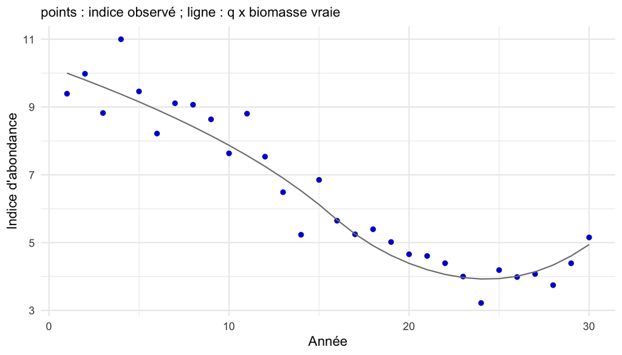

```r
set.seed(1)                    # pour obtenir toujours le même bruit
r_vrai <- 0.4
K_vrai <- 1000
q_vrai <- 0.01
annees <- 1:30
captures <- c(seq(20, 140, length.out = 15), seq(140, 60, length.out = 15))
B_vrai <- simuler_serie(B0 = K_vrai, r_vrai, K_vrai, captures)
# indice = q * B, multiplié par une erreur aléatoire d'environ 10 %
indice <- q_vrai * B_vrai * exp(rnorm(30, mean = 0, sd = 0.1))

simu <- data.frame(annee = annees, captures = captures, B = B_vrai, indice = indice)
ggplot(simu, aes(annee, indice)) +
  geom_point(colour = "blue3") +
  geom_line(aes(y = q_vrai * B), colour = "grey50") +
  labs(x = "Année", y = "Indice d'abondance",
       subtitle = "points : indice observé ; ligne : q x biomasse vraie") +
  theme_minimal()
```

## 3.2 La fonction de coût

La fonction de coût prend les paramètres, simule la biomasse avec les captures observées, calcule l’indice prédit $\hat I_t = q\,\hat B_t$ et renvoie la somme des carrés des écarts avec l’indice observé :

$$S(r, K, q) = \sum_t \left[\ln I_t - \ln(q\,\hat B_t)\right]^2$$

Deux astuces :

- on compare les **logarithmes** des indices, car les erreurs d’un indice d’abondance sont plutôt proportionnelles (multiplicatives) ;
- on fait chercher à `optim()` le **logarithme** des paramètres : `exp(par)` est toujours positif, ce qui évite des valeurs absurdes ($r$ ou $K$ négatifs).

On suppose enfin que le stock est **vierge** la première année : $B_1 = K$.

```r
sce_schaefer <- function(par, captures, indice) {
  r <- exp(par[1])
  K <- exp(par[2])
  q <- exp(par[3])
  B <- simuler_serie(B0 = K, r, K, captures)
  B <- pmax(B, 1e-6)                  # évite log(0) si le stock s'effondre
  sum((log(indice) - log(q * B))^2)
}

# coût avec les vraies valeurs, puis avec de mauvaises valeurs
sce_schaefer(log(c(0.4, 1000, 0.01)), captures, indice)
```

```
[1] 0.2496996
```

```r
sce_schaefer(log(c(0.2, 2000, 0.005)), captures, indice)
```

```
[1] 1.946922
```

## 3.3 Ajuster

```r
depart <- log(c(0.2, 2000, 0.005))   # valeurs de départ (r, K, q)
fit <- optim(depart, sce_schaefer, captures = captures, indice = indice,
             control = list(maxit = 5000))
fit$convergence                      # 0 = l'algorithme a convergé
```

```
[1] 0
```

```r
estim <- exp(fit$par)
names(estim) <- c("r", "K", "q")
estim
```

```
           r            K            q
3.497222e-01 1.104215e+03 9.165943e-03
```

### 3.3.1 À vous

1. Comparez les estimations de $r$, $K$ et $q$ avec les vraies valeurs.
2. Calculez le MSY, $B_{MSY}$ et $F_{MSY}$ estimés et vrais.
3. Simulez la biomasse avec les paramètres estimés et tracez-la avec la biomasse vraie. Tracez aussi l’indice observé et l’indice prédit.

```r
# votre code ici
```

*(commentez ici)*

## 3.4 Quand l’ajustement échoue : le manque de contraste

### 3.4.1 À vous

Recommencez avec des captures qui ne font qu’**augmenter**, de 20 à 120 t sur 30 ans (`seq(20, 120, length.out = 30)`) : générez un nouvel indice, puis ajustez le modèle. Que constatez-vous ?

```r
# votre code ici
```

*(commentez ici)*

# 4 Un exemple réel : le thon germon de l’Atlantique Sud

Le fichier `data/albacore.dat` contient les captures (en milliers de tonnes) et la CPUE des palangriers (en kg pour 100 hameçons) du **thon germon** (*Thunnus alalunga*, « albacore » en anglais) de l’Atlantique Sud, de 1967 à 1989. Ces données ont été utilisées par Polacheck, Hilborn et Punt (1993) pour comparer les méthodes d’ajustement des modèles de production. Attention au faux ami : Schaefer travaillait, lui, sur l’*albacore* au sens français, le thon à nageoires jaunes du Pacifique Est.

```r
germon <- read.table("data/albacore.dat", header = TRUE)
str(germon)
```

```
'data.frame':   23 obs. of  3 variables:
 $ Year : int  1967 1968 1969 1970 1971 1972 1973 1974 1975 1976 ...
 $ Catch: num  15.9 25.7 28.5 23.7 25 33.3 28.2 19.7 17.5 19.3 ...
 $ Index: num  61.9 79 55.6 44.6 56.9 ...
```

### 4.0.1 À vous

1. Représentez les captures et la CPUE au cours du temps. Que suggère la CPUE ?
2. Ajustez le modèle de Schaefer (valeurs de départ suggérées : $r = 0{,}3$, $K = 250$, $q = 0{,}25$). Donnez $r$, $K$, $q$, le MSY, $B_{MSY}$ et $F_{MSY}$.
3. Tracez la CPUE observée et prédite.
4. Calculez pour chaque année $B/B_{MSY}$ et $F/F_{MSY}$, avec $F = C/B$. Dans quel état est le stock en 1989 ? Les captures des dernières années sont-elles durables ?

```r
# votre code ici
```

*(commentez ici)*

# 5 Synthèse

En quelques phrases :

1. Quelles données faut-il pour ajuster un modèle de Schaefer ?
2. Pourquoi ajuste-t-on le logarithme de l’indice et des paramètres ?
3. Pourquoi l’ajustement peut-il échouer même quand le modèle est le bon ?

*(rédigez ici)*

**NotePour aller plus loin**

Le package **MQMF** (Haddon 2020) fournit des fonctions toutes prêtes pour ajuster ce modèle (`fitSPM()`), évaluer l’incertitude par bootstrap (`spmboot()`) et faire des projections (`spmproj()`). Les modèles utilisés aujourd’hui, comme SPiCT, ajoutent une erreur sur la dynamique elle-même (erreur de processus) et quantifient l’incertitude des estimations.